# 09_analysis

1. Introduction
2. Notebook settings
3. Data Loading, Cleaning and Initial Exploration
4. Data Preparation
5. EDA
6. Statistical Inference and Hypothesis Testing
7. Data Preprocessing
8. Data Modeling
9. Hyperparameter Tuning
10. Ensemble Model Approach with Optimized Classifiers
11. Cross-Validation Performance
12. Practicing AutoML: H2O.ai
13. Learning Curves
14. LIME Interpretation
15. AUC-ROC Curves for the Ensemble Model
16. Generating Predictions for Test Set and Preparing Submission File
17. Final Conclusion
18. Suggested Improvements

## Introduction

Project Introduction: Predicting Passenger Transport on the Spaceship Titanic

This project was conducted as part of the Kaggle competition, Spaceship Titanic, which involves predicting whether passengers were transported to an alternate dimension during their journey. Inspired by the classic Titanic disaster, the competition adds a sci-fi twist, where passengers aboard the “Spaceship Titanic” are unexpectedly caught in an anomaly, and only some are transported to a different dimension.

Reference: https://www.kaggle.com/competitions/spaceship-titanic/overview

Score: minimum 0.79, according to the project requirements.

## Dataset Structure

File and Data Field Descriptions

| Column | Description |
| --- | --- |
| PassengerId | A unique Id for each passenger. Each Id takes the form gggg_pp where gggg indicates a group the passenger is travelling with and pp is their number within the group. People in a group are often family… |
| HomePlanet | The planet the passenger departed from, typically their planet of permanent residence. |
| CryoSleep | Indicates whether the passenger elected to be put into suspended animation for the duration of the voyage. Passengers in cryosleep are confined to their cabins. |
| Cabin | The cabin number where the passenger is staying. Takes the form deck/num/side, where side can be either P for Port or S for Starboard. |
| Destination | The planet the passenger will be debarking to. |
| Age | The age of the passenger. |
| VIP | Whether the passenger has paid for special VIP service during the voyage. |
| RoomService, FoodCourt, ShoppingMall, Spa, VRDeck | Amount the passenger has billed at each of the Spaceship Titanic's many luxury amenities. |
| Name | The first and last names of the passenger. |
| Transported | Whether the passenger was transported to another dimension. This is the target, the column you are trying to predict. |

- Datasets:

| Dataset | Description |
| --- | --- |
| train.csv | Personal records for about two-thirds (~8700) of the passengers, to be used as training data. |
| test.csv | Personal records for the remaining one-third (~4300) of the passengers, to be used as test data. The task is to predict the value of Transported for the passengers in this set. |
| sample_submission.csv | A sample submission file in the correct format. |

- Target Variable:

| Target | Description |
| --- | --- |
| Transported | The target variable. For each passenger, predict either True or False. |

## Notebook settings

```python
from assets.utils.functions import *
```

```python
# Core libraries and configurations
import math
import warnings
import joblib
from typing import Dict, Tuple, List, Any, NoReturn, Optional
import pandas as pd
import numpy as np
import lightgbm as lgb
from contextlib import contextmanager
import sys
import os
warnings.filterwarnings("ignore", message="The default of observed=False is deprecated")

# Data analysis and manipulation
import sidetable as stb
from skimpy import skim

# Statistical analysis and hypothesis testing
import scipy.stats as stats
from scipy.stats import norm, ttest_ind, chi2_contingency, t, zscore
import statsmodels.api as sms
import statsmodels.stats.api as sms_stats
from statsmodels.stats.weightstats import CompareMeans, DescrStatsW
from statsmodels.stats.outliers_influence import variance_inflation_factor

# Visualization tools
import seaborn as sns
import matplotlib.pyplot as plt
import matplotlib.patches as mpatches

# Machine learning and preprocessing
from sklearn import ensemble, linear_model, neighbors, svm, tree
from sklearn.compose import ColumnTransformer
from sklearn.ensemble import (
    RandomForestClassifier, RandomForestRegressor, GradientBoostingClassifier,
    HistGradientBoostingClassifier, VotingClassifier
)
from sklearn.linear_model import LinearRegression, LogisticRegression
from sklearn.inspection import permutation_importance
from sklearn.metrics import (
    accuracy_score, mean_squared_error, mean_absolute_error, r2_score, f1_score,
    classification_report, roc_auc_score, confusion_matrix, roc_curve,
    plot_confusion_matrix, plot_roc_curve, plot_precision_recall_curve
)
from sklearn.model_selection import (
    train_test_split, cross_val_score, learning_curve, StratifiedKFold, GridSearchCV,
    RandomizedSearchCV, ShuffleSplit
)
from sklearn.pipeline import Pipeline
from sklearn.preprocessing import (
    StandardScaler, OneHotEncoder, OrdinalEncoder, LabelEncoder, PolynomialFeatures
)
from sklearn.tree import DecisionTreeClassifier

# Advanced machine learning algorithms (MLAs)
from xgboost import XGBClassifier
from lightgbm import LGBMClassifier
from catboost import CatBoostClassifier
from imblearn.ensemble import BalancedRandomForestClassifier, EasyEnsembleClassifier

# Categorical encoding
from category_encoders import TargetEncoder
```

```python
%load_ext pycodestyle_magic
# %reload_ext pycodestyle_magic
%pycodestyle_on
%flake8_on
%flake8_on --max_line_length 79
%matplotlib inline
```

## Data Loading, Cleaning and Initial Exploration

```python
# Load a dataset into a Pandas Dataframe
train_df = pd.read_csv('./assets/data/train.csv')
test_df = pd.read_csv('./assets/data/test.csv')
print("Full train dataset shape is {}".format(train_df.shape))
print("Full test dataset shape is {}".format(test_df.shape))

# Additional datasets to be used for analysis
train_adj_df = train_df.copy(deep=True)

# List of datasets to be cleaned (if needed)
clean_df_list = [train_adj_df, test_df]
```

```
Full train dataset shape is (8693, 14)
Full test dataset shape is (4277, 13)
```

There are 14 feature columns. Using these features your model has to predict whether the passenger is rescued or not indicated by the column Transported.

```python
train_adj_df.head()
```

|  | PassengerId | HomePlanet | CryoSleep | Cabin | Destination | Age | VIP | RoomService | FoodCourt | ShoppingMall | Spa | VRDeck | Name | Transported |
| --- | --- | --- | --- | --- | --- | --- | --- | --- | --- | --- | --- | --- | --- | --- |
| 0 | 0001_01 | Europa | False | B/0/P | TRAPPIST-1e | 39.0 | False | 0.0 | 0.0 | 0.0 | 0.0 | 0.0 | Maham Ofracculy | False |
| 1 | 0002_01 | Earth | False | F/0/S | TRAPPIST-1e | 24.0 | False | 109.0 | 9.0 | 25.0 | 549.0 | 44.0 | Juanna Vines | True |
| 2 | 0003_01 | Europa | False | A/0/S | TRAPPIST-1e | 58.0 | True | 43.0 | 3576.0 | 0.0 | 6715.0 | 49.0 | Altark Susent | False |
| 3 | 0003_02 | Europa | False | A/0/S | TRAPPIST-1e | 33.0 | False | 0.0 | 1283.0 | 371.0 | 3329.0 | 193.0 | Solam Susent | False |
| 4 | 0004_01 | Earth | False | F/1/S | TRAPPIST-1e | 16.0 | False | 303.0 | 70.0 | 151.0 | 565.0 | 2.0 | Willy Santantines | True |

```python
test_df.head()
```

|  | PassengerId | HomePlanet | CryoSleep | Cabin | Destination | Age | VIP | RoomService | FoodCourt | ShoppingMall | Spa | VRDeck | Name |
| --- | --- | --- | --- | --- | --- | --- | --- | --- | --- | --- | --- | --- | --- |
| 0 | 0013_01 | Earth | True | G/3/S | TRAPPIST-1e | 27.0 | False | 0.0 | 0.0 | 0.0 | 0.0 | 0.0 | Nelly Carsoning |
| 1 | 0018_01 | Earth | False | F/4/S | TRAPPIST-1e | 19.0 | False | 0.0 | 9.0 | 0.0 | 2823.0 | 0.0 | Lerome Peckers |
| 2 | 0019_01 | Europa | True | C/0/S | 55 Cancri e | 31.0 | False | 0.0 | 0.0 | 0.0 | 0.0 | 0.0 | Sabih Unhearfus |
| 3 | 0021_01 | Europa | False | C/1/S | TRAPPIST-1e | 38.0 | False | 0.0 | 6652.0 | 0.0 | 181.0 | 585.0 | Meratz Caltilter |
| 4 | 0023_01 | Earth | False | F/5/S | TRAPPIST-1e | 20.0 | False | 10.0 | 0.0 | 635.0 | 0.0 | 0.0 | Brence Harperez |

```python
skim(train_adj_df)
```

```
╭──────────────────────────────────────────────── skimpy summary ─────────────────────────────────────────────────╮
│          Data Summary                Data Types                                                                 │
│ ┏━━━━━━━━━━━━━━━━━━━┳━━━━━━━━┓ ┏━━━━━━━━━━━━━┳━━━━━━━┓                                                          │
│ ┃ dataframe         ┃ Values ┃ ┃ Column Type ┃ Count ┃                                                          │
│ ┡━━━━━━━━━━━━━━━━━━━╇━━━━━━━━┩ ┡━━━━━━━━━━━━━╇━━━━━━━┩                                                          │
│ │ Number of rows    │ 8693   │ │ float64     │ 6     │                                                          │
│ │ Number of columns │ 14     │ │ string      │ 5     │                                                          │
│ └───────────────────┴────────┘ │ bool        │ 3     │                                                          │
│                                └─────────────┴───────┘                                                          │
│                                                     number                                                      │
│ ┏━━━━━━━━━━━━━━━━━━━┳━━━━━━━┳━━━━━━━━┳━━━━━━━━━━┳━━━━━━━━━━┳━━━━━━┳━━━━━━━┳━━━━━━━┳━━━━━━┳━━━━━━━━━┳━━━━━━━━━┓  │
│ ┃ column_name       ┃ NA    ┃ NA %   ┃ mean     ┃ sd       ┃ p0   ┃ p25   ┃ p50   ┃ p75  ┃ p100    ┃ hist    ┃  │
│ ┡━━━━━━━━━━━━━━━━━━━╇━━━━━━━╇━━━━━━━━╇━━━━━━━━━━╇━━━━━━━━━━╇━━━━━━╇━━━━━━━╇━━━━━━━╇━━━━━━╇━━━━━━━━━╇━━━━━━━━━┩  │
│ │ Age               │   179 │   2.06 │    28.83 │    14.49 │    0 │    19 │    27 │   38 │      79 │  ▂▇▆▃▁  │  │
│ │ RoomService       │   181 │   2.08 │    224.7 │    666.7 │    0 │     0 │     0 │   47 │   14330 │    ▇    │  │
│ │ FoodCourt         │   183 │   2.11 │    458.1 │     1611 │    0 │     0 │     0 │   76 │   29810 │    ▇    │  │
│ │ ShoppingMall      │   208 │   2.39 │    173.7 │    604.7 │    0 │     0 │     0 │   27 │   23490 │    ▇    │  │
│ │ Spa               │   183 │   2.11 │    311.1 │     1137 │    0 │     0 │     0 │   59 │   22410 │    ▇    │  │
│ │ VRDeck            │   188 │   2.16 │    304.9 │     1146 │    0 │     0 │     0 │   46 │   24130 │    ▇    │  │
│ └───────────────────┴───────┴────────┴──────────┴──────────┴──────┴───────┴───────┴──────┴─────────┴─────────┘  │
│                                                      bool                                                       │
│ ┏━━━━━━━━━━━━━━━━━━━━━━━━━━━━━━━━━━━━┳━━━━━━━━━━━━━━━━━┳━━━━━━━━━━━━━━━━━━━━━━━━━━━━━━━┳━━━━━━━━━━━━━━━━━━━━━┓  │
│ ┃ column_name                        ┃ true            ┃ true rate                     ┃ hist                ┃  │
│ ┡━━━━━━━━━━━━━━━━━━━━━━━━━━━━━━━━━━━━╇━━━━━━━━━━━━━━━━━╇━━━━━━━━━━━━━━━━━━━━━━━━━━━━━━━╇━━━━━━━━━━━━━━━━━━━━━┩  │
│ │ CryoSleep                          │            3254 │                          0.37 │       ▇    ▅        │  │
│ │ VIP                                │             402 │                         0.046 │          ▇          │  │
│ │ Transported                        │            4378 │                           0.5 │       ▇    ▇        │  │
│ └────────────────────────────────────┴─────────────────┴───────────────────────────────┴─────────────────────┘  │
│                                                     string                                                      │
│ ┏━━━━━━━━━━━━━━━━━━━━━━━━━━┳━━━━━━━━━━┳━━━━━━━━━━━━┳━━━━━━━━━━━━━━━━━━━━━━━━━━━━━━┳━━━━━━━━━━━━━━━━━━━━━━━━━━┓  │
│ ┃ column_name              ┃ NA       ┃ NA %       ┃ words per row                ┃ total words              ┃  │
│ ┡━━━━━━━━━━━━━━━━━━━━━━━━━━╇━━━━━━━━━━╇━━━━━━━━━━━━╇━━━━━━━━━━━━━━━━━━━━━━━━━━━━━━╇━━━━━━━━━━━━━━━━━━━━━━━━━━┩  │
│ │ PassengerId              │        0 │          0 │                            1 │                     8693 │  │
│ │ HomePlanet               │      201 │       2.31 │                         0.98 │                     8492 │  │
│ │ Cabin                    │      199 │       2.29 │                         0.98 │                     8494 │  │
│ │ Destination              │      182 │       2.09 │                          1.5 │                    12907 │  │
│ │ Name                     │      200 │        2.3 │                            2 │                    16986 │  │
│ └──────────────────────────┴──────────┴────────────┴──────────────────────────────┴──────────────────────────┘  │
╰────────────────────────────────────────────────────── End ──────────────────────────────────────────────────────╯
```

```python
check_distinct_values(train_adj_df)
```

```
Distinct values for 'PassengerId': ['0001_01' '0002_01' '0003_01' ... '9279_01' '9280_01' '9280_02']
Distinct values for 'HomePlanet': ['Europa' 'Earth' 'Mars' nan]
Distinct values for 'CryoSleep': [False True nan]
Distinct values for 'Cabin': ['B/0/P' 'F/0/S' 'A/0/S' ... 'G/1499/S' 'G/1500/S' 'E/608/S']
Distinct values for 'Destination': ['TRAPPIST-1e' 'PSO J318.5-22' '55 Cancri e' nan]
Distinct values for 'VIP': [False True nan]
Distinct values for 'Name': ['Maham Ofracculy' 'Juanna Vines' 'Altark Susent' ... 'Fayey Connon'
 'Celeon Hontichre' 'Propsh Hontichre']
```

```python
print(f"\nNumber of duplicate rows: {train_adj_df.duplicated().sum()}")
```

```
Number of duplicate rows: 0
```

```python
check_blank_or_whitespace(train_adj_df)
```

```
Count of empty strings or single spaces per column:
PassengerId     0
HomePlanet      0
CryoSleep       0
Cabin           0
Destination     0
Age             0
VIP             0
RoomService     0
FoodCourt       0
ShoppingMall    0
Spa             0
VRDeck          0
Name            0
Transported     0
dtype: int64
```

```python
train_adj_df.info()
```

```
<class 'pandas.core.frame.DataFrame'>
RangeIndex: 8693 entries, 0 to 8692
Data columns (total 14 columns):
 #   Column        Non-Null Count  Dtype
---  ------        --------------  -----
 0   PassengerId   8693 non-null   object
 1   HomePlanet    8492 non-null   object
 2   CryoSleep     8476 non-null   object
 3   Cabin         8494 non-null   object
 4   Destination   8511 non-null   object
 5   Age           8514 non-null   float64
 6   VIP           8490 non-null   object
 7   RoomService   8512 non-null   float64
 8   FoodCourt     8510 non-null   float64
 9   ShoppingMall  8485 non-null   float64
 10  Spa           8510 non-null   float64
 11  VRDeck        8505 non-null   float64
 12  Name          8493 non-null   object
 13  Transported   8693 non-null   bool
dtypes: bool(1), float64(6), object(7)
memory usage: 891.5+ KB
```

### Outliers Analysis

The goal here is to identify the outliers in the dataset and understand whether they are valid or not. If they are valid, we will keep them as it is. If they are invalid, we will take a different approach to handle them.

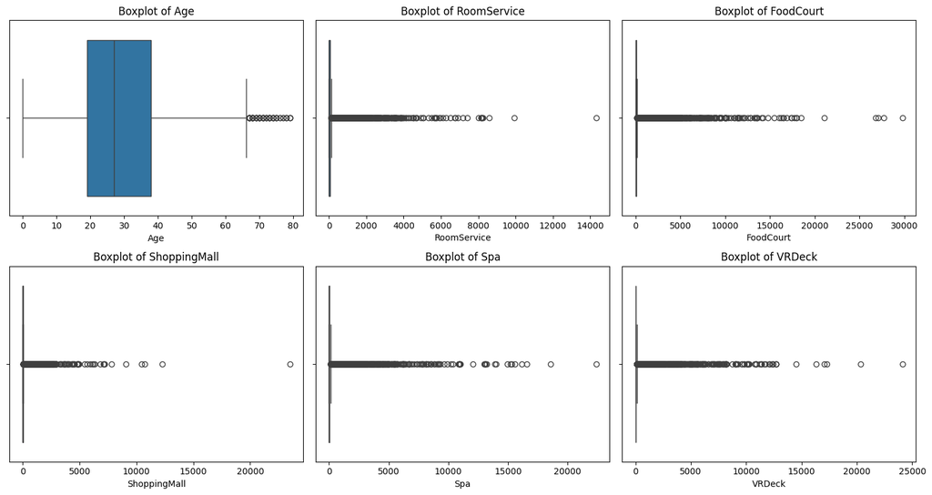

```python
# List of numerical columns to check for outliers
numerical_columns = ['Age', 'RoomService', 'FoodCourt',
                     'ShoppingMall', 'Spa', 'VRDeck']

# Set up the figure for boxplots
plt.figure(figsize=(15, 8))
for i, col in enumerate(numerical_columns, 1):
    plt.subplot(2, 3, i)
    sns.boxplot(data=train_adj_df, x=col)
    plt.title(f"Boxplot of {col}")
plt.tight_layout()
plt.show()
```

### Conclusion for Outliers Analysis

1. **Age:**
- The distribution of ages appears reasonable, with some natural variability up to around 80 years, which is plausible. No outlier treatment is likely needed here, as these values seem realistic.
2. **RoomService, FoodCourt, ShoppingMall, Spa, VRDeck:**
- These features have numerous extreme outliers. Spending amounts in each category have a large range, which might indicate a small number of passengers with unusually high spending.

Since Age seems reasonable, I will not treat the outliers in this case. However, I will further investigate them as to see if the spending could be related to VIP feature and see if it would need an addtional approach.

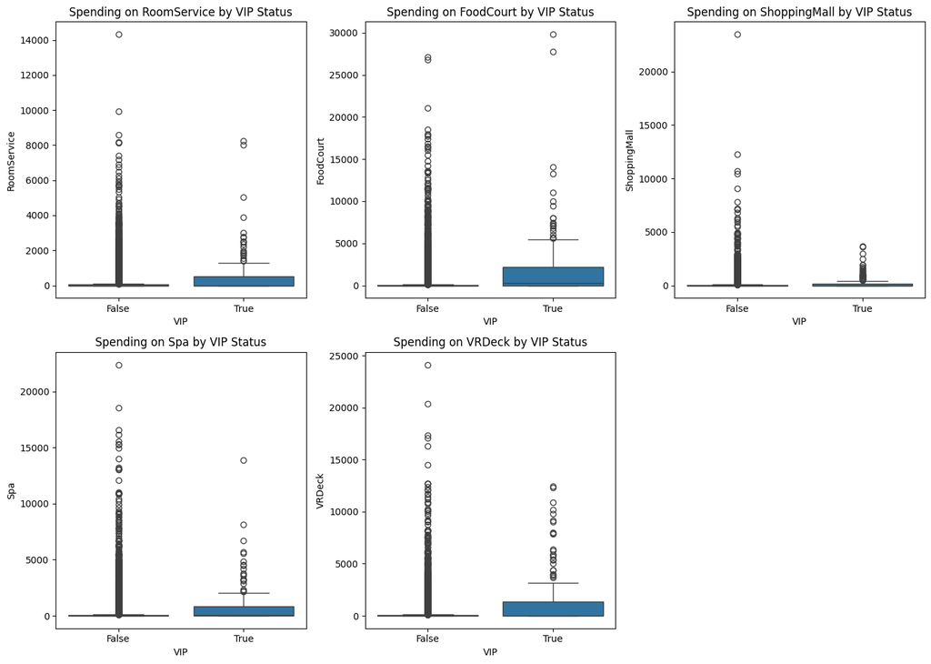

```python
# List of numerical columns to check for outliers
spending_columns = ['RoomService', 'FoodCourt',
                    'ShoppingMall', 'Spa', 'VRDeck']

# Create boxplots for each spending column by VIP status
plt.figure(figsize=(14, 10))
for i, col in enumerate(spending_columns, 1):
    plt.subplot(2, 3, i)
    sns.boxplot(data=train_adj_df, x='VIP', y=col)
    plt.title(f"Spending on {col} by VIP Status")
plt.tight_layout()
plt.show()
```

### Conclusion for Outliers Analysis and VIP Feature

Non-VIPs display a wider range of spending patterns, including more extreme outliers. This could indicate that some non-VIPs engage heavily with amenities, possibly marking them as potential candidates for VIP services. Overall, VIPs use amenities predictably, while non-VIPs vary more in their spending behavior.

Since the spending amounts are reasonable and the VIP feature is informative, I will keep the outliers as they are.

## Data Preparation

### Strategy for missing data

I will now check for missing data in the dataset and decide on a strategy to handle them.

```python
train_null_summary = calculate_null_total_and_percentage(train_adj_df)
test_null_summary = calculate_null_total_and_percentage(test_df)

# Print the summaries
print("Train columns with total and percentage of null values:\n",
      train_null_summary)
print("-" * 50)
print("Test/Validation columns with total and percentage of null values:\n",
      test_null_summary)
```

```
Train columns with total and percentage of null values:
               Total Missing  Percentage Missing
PassengerId               0            0.000000
HomePlanet              201            2.312205
CryoSleep               217            2.496261
Cabin                   199            2.289198
Destination             182            2.093639
Age                     179            2.059128
VIP                     203            2.335212
RoomService             181            2.082135
FoodCourt               183            2.105142
ShoppingMall            208            2.392730
Spa                     183            2.105142
VRDeck                  188            2.162660
Name                    200            2.300702
Transported               0            0.000000
--------------------------------------------------
Test/Validation columns with total and percentage of null values:
               Total Missing  Percentage Missing
PassengerId               0            0.000000
HomePlanet               87            2.034136
CryoSleep                93            2.174421
Cabin                   100            2.338087
Destination              92            2.151040
Age                      91            2.127660
VIP                      93            2.174421
RoomService              82            1.917232
FoodCourt               106            2.478373
ShoppingMall             98            2.291326
Spa                     101            2.361468
VRDeck                   80            1.870470
Name                     94            2.197802
```

### Insights and Approach definition

All of the features have a relatively low percentage of missing values (around 2-2.5%). This means that handling these missing values is important but should not require overly complex techniques since the percentage is small.

1. **HomePlanet, CryoSleep, VIP, and Destination (Categorical Features)**
- **Imputation with Mode:** These features can be imputed using the mode (most frequent value), as the missing percentages are small, and the mode will preserve the distribution of these categories.
2. **Age (Numerical Feature)**
- **Imputation with Mean or Median:** Since this is a numerical feature, impute missing values with the mean or median of the feature. Median is often more robust against outliers.
3. **RoomService, FoodCourt, ShoppingMall, Spa, and VRDeck (Numerical Features)**
- **Imputation with 0:** These features are likely to be transactional data, and missing values can be imputed with 0, assuming that no transaction was made.
4. **Dropping Features**
- **PassengerId:**
- Reason for Dropping: PassengerId is a unique identifier for each passenger and does not contain any meaningful information about the passenger’s likelihood of being transported. It is not a feature that contributes to the predictive power of the model since it doesn’t provide patterns or relationships to the target variable (Transported).
- Purpose in Test Data: It is still essential to retain PassengerId in the test set to correctly identify passengers in the final predictions when submitting results.
- **Cabin:**
- Reason for Dropping: The Cabin column, while potentially informative, was removed to simplify the dataset. Although it could provide some useful details, such as deck or location, analyzing it directly would add complexity without immediate clarity or a clear impact on the prediction task. By excluding this column, the dataset remains more manageable, focusing on features with more straightforward, interpretable values.
- **Name:**
- Reason for Dropping: While the Name column could theoretically provide information such as titles (e.g., Mr., Miss.), the name itself is not directly useful in predicting whether someone was transported. Names are generally considered irrelevant for most machine learning models unless specifically engineered into features (e.g., extracting titles, family groups). Since extracting useful information from the Name column was not part of the scope, it can be dropped to simplify the feature set.

```python
# Disable flake8 for this cell
# flake8: noqa

for dataset in clean_df_list:
    # Convert 'CryoSleep' and 'VIP' to 'object' for imputation
    dataset['CryoSleep'] = dataset['CryoSleep'].astype('object')
    dataset['VIP'] = dataset['VIP'].astype('object')

    # Mode imputation for categorical columns
    mode_imputer = SimpleImputer(strategy='most_frequent')
    dataset['HomePlanet'] = mode_imputer.fit_transform(
        dataset[['HomePlanet']]).ravel()
    dataset['CryoSleep'] = mode_imputer.fit_transform(
        dataset[['CryoSleep']]).ravel()
    dataset['VIP'] = mode_imputer.fit_transform(
        dataset[['VIP']]).ravel()
    dataset['Destination'] = mode_imputer.fit_transform(
        dataset[['Destination']]).ravel()

    # Convert 'CryoSleep' and 'VIP' back to boolean
    dataset['CryoSleep'] = dataset['CryoSleep'].astype(bool)
    dataset['VIP'] = dataset['VIP'].astype(bool)

    # Median imputation for 'Age'
    median_imputer = SimpleImputer(strategy='median')
    dataset['Age'] = median_imputer.fit_transform(dataset[['Age']]).ravel()

    # Fill missing values with 0 for spending-related columns
    dataset[['RoomService', 'FoodCourt',
             'ShoppingMall', 'Spa', 'VRDeck']] = dataset[[
                 'RoomService', 'FoodCourt',
                 'ShoppingMall', 'Spa', 'VRDeck']].fillna(0)

    # Drop unnecessary features for both training and test datasets
    drop_features = ['Cabin', 'Name']
    dataset.drop(drop_features, axis=1, inplace=True)

# Dropping unnecessary features - Train dataset
drop_feat_id = ['PassengerId']
train_adj_df.drop(drop_feat_id, axis=1, inplace=True)

# Print information to verify the process
print(f"Train dataset after imputation and dropping features:\n",
      train_adj_df.isnull().sum())
print("-"*50)
print(f"Test dataset after imputation and dropping features:\n",
      test_df.isnull().sum())

# Re-enable flake8 for the next cells if desired
%flake8_on
```

```
Train dataset after imputation and dropping features:
 HomePlanet      0
CryoSleep       0
Destination     0
Age             0
VIP             0
RoomService     0
FoodCourt       0
ShoppingMall    0
Spa             0
VRDeck          0
Transported     0
dtype: int64
--------------------------------------------------
Test dataset after imputation and dropping features:
 PassengerId     0
HomePlanet      0
CryoSleep       0
Destination     0
Age             0
VIP             0
RoomService     0
FoodCourt       0
ShoppingMall    0
Spa             0
VRDeck          0
dtype: int64
```

### Feature Engineering - TotalSpending

By summing up the amounts spent on different services (e.g., RoomService, FoodCourt, ShoppingMall, Spa, and VRDeck), I can capture a broader indicator of a passenger’s spending habits. High or low total spending might correlate with different passenger behaviors, such as whether they were in cryo-sleep or participated in certain luxury activities. This could be a strong predictor of the target variable, Transported.

**Important Note: Reducing Dimensionality**

Also, combining several spending features into one helps reduce the dimensionality of the dataset without losing much information. This can help models generalize better by simplifying relationships. Instead of modeling individual spending habits, the model can focus on the total amount.

```python
# Create the TotalSpending feature
for dataset in clean_df_list:
    dataset['TotalSpending'] = dataset[
        ['RoomService', 'FoodCourt',
         'ShoppingMall', 'Spa', 'VRDeck']].sum(axis=1)

# Print information about train_adj_df and test_df
print("Train dataset after Feature Engineering:")
train_adj_df.info()
print("-" * 50)

print("Test dataset after Feature Engineering:")
test_df.info()
```

```
Train dataset after Feature Engineering:
<class 'pandas.core.frame.DataFrame'>
RangeIndex: 8693 entries, 0 to 8692
Data columns (total 12 columns):
 #   Column         Non-Null Count  Dtype
---  ------         --------------  -----
 0   HomePlanet     8693 non-null   object
 1   CryoSleep      8693 non-null   bool
 2   Destination    8693 non-null   object
 3   Age            8693 non-null   float64
 4   VIP            8693 non-null   bool
 5   RoomService    8693 non-null   float64
 6   FoodCourt      8693 non-null   float64
 7   ShoppingMall   8693 non-null   float64
 8   Spa            8693 non-null   float64
 9   VRDeck         8693 non-null   float64
 10  Transported    8693 non-null   bool
 11  TotalSpending  8693 non-null   float64
dtypes: bool(3), float64(7), object(2)
memory usage: 636.8+ KB
--------------------------------------------------
Test dataset after Feature Engineering:
<class 'pandas.core.frame.DataFrame'>
RangeIndex: 4277 entries, 0 to 4276
Data columns (total 12 columns):
 #   Column         Non-Null Count  Dtype
---  ------         --------------  -----
 0   PassengerId    4277 non-null   object
 1   HomePlanet     4277 non-null   object
 2   CryoSleep      4277 non-null   bool
 3   Destination    4277 non-null   object
 4   Age            4277 non-null   float64
 5   VIP            4277 non-null   bool
 6   RoomService    4277 non-null   float64
 7   FoodCourt      4277 non-null   float64
 8   ShoppingMall   4277 non-null   float64
 9   Spa            4277 non-null   float64
 10  VRDeck         4277 non-null   float64
 11  TotalSpending  4277 non-null   float64
dtypes: bool(2), float64(7), object(3)
memory usage: 342.6+ KB
```

However, it’s a good idea to keep individual feature so then I can experiment different approaches:

1. **With individual features:** Keep both the individual features and TotalSpending to see if the individual spending habits provide additional predictive power.
2. **Without individual features:** Drop them and use only TotalSpending. This simplifies the model and reduces the risk of overfitting to the individual features.

For now I will keep the individual features and add TotalSpending to the dataset.

### Binning Features: Age and TotalSpending

This step involves converting continuous numerical features (Age and TotalSpending) into categorical features by binning them into groups. Binning can help capture non-linear relationships and patterns in the data, especially when the target variable shows different behaviors across these groups. Also can be a good approach for EDA and feature selection. Bins would be defined as below:

1. **Age:**
- 0 - 18: Young
- 19 - 35: Adult
- 36 - 60: Middle Aged
- 61+: Senior
2. **TotalSpending:**
- 0: Non-Spenders (no spending at all)
- 1 to 716: Low Spenders
- 717 to 1441: Medium Spenders
- 1442 to 35987: High Spenders

```python
# Custom bins based on age distribution
age_bins = [-float('inf'), 18, 35, 60, float('inf')]
age_labels = ['Young', 'Adult', 'Middle Aged', 'Senior']

# Custom bins based on TotalSpending distribution
spending_bins = [-float('inf'), 0, 716, 1441, float('inf')]
spending_labels = ['Non-Spender', 'Low Spender',
                   'Medium Spender', 'High Spender']

# Create Bins for each dataset in clean_df_list
for dataset in clean_df_list:
    dataset['AgeBin'] = pd.cut(
        dataset['Age'], bins=age_bins,
        labels=age_labels)
    dataset['SpendingBin'] = pd.cut(
        dataset['TotalSpending'], bins=spending_bins,
        labels=spending_labels)
```

## EDA

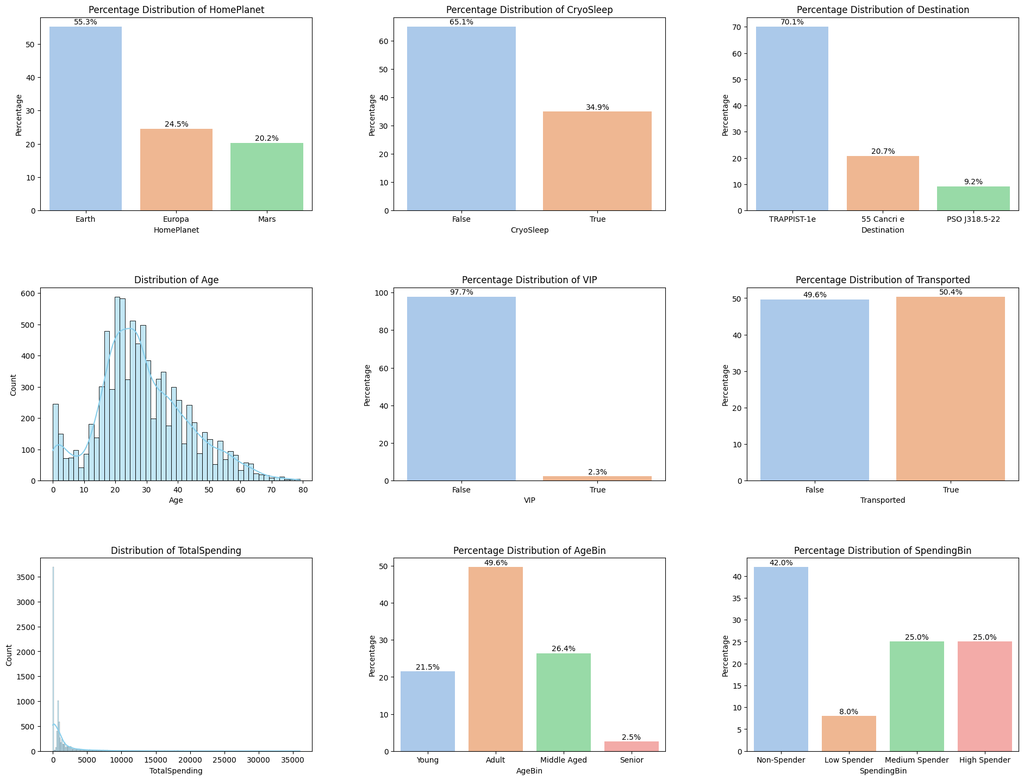

```python
univariate_df_train = train_adj_df.copy()
univariate_df_train.drop(columns=['RoomService', 'FoodCourt',
                                  'ShoppingMall', 'Spa',
                                  'VRDeck'], inplace=True)
univariate_analysis(univariate_df_train)
```

### Conclusion for Univariate Analysis after data imputation

In summary, the passenger population primarily consists of younger, Earth-based travelers heading to TRAPPIST-1e, with a large portion having minimal spending habits and only a small percentage availing VIP services. The target variable, Transported, is evenly balanced, making this dataset suitable for predictive analysis without heavy class imbalance adjustments.

### Bivariate Analysis

Now the goal is to understand the relationship between the features and the target variable, Transported. This will help identify which features are more likely to influence the target and provide insights into the predictive power of each feature.

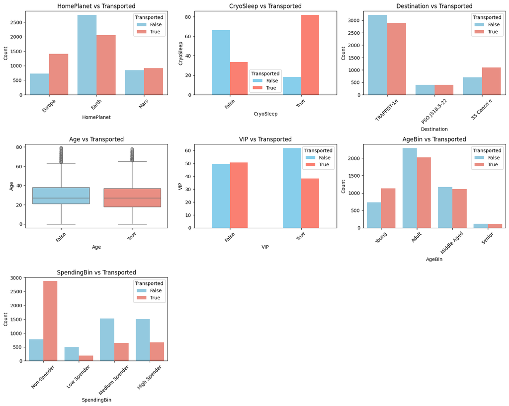

```python
bivariate_df_train = train_adj_df.copy(deep=True)
bivariate_df_train.drop(columns=['RoomService', 'FoodCourt',
                                 'ShoppingMall', 'Spa', 'VRDeck',
                                 'TotalSpending'], inplace=True)
features_vs_target(bivariate_df_train)
```

### Conclusion over Bivariate Analysis

**Conclusion:**

Certain features, notably HomePlanet, CryoSleep, Destination, and SpendingBin, show potential associations with the likelihood of being transported, while others, such as VIP status and Age (as a continuous variable), appear less influential.